# Traffic Sign Recognition

In this notebook I will provide you with all the basic steps you need to do you to make your own code for doing traffic sign recognition or any other data recognition you need. Please feel free to use this code for your own projects.

## Step 0: Load The Data

```python
# Load pickled data
import pickle
import csv

data_folder = 'traffic-signs-data/'
training_file = data_folder + 'train.p'
validation_file= data_folder + 'valid.p'
testing_file = data_folder + 'test.p'

with open(training_file, mode='rb') as f:
    train = pickle.load(f)
with open(validation_file, mode='rb') as f:
    valid = pickle.load(f)
with open(testing_file, mode='rb') as f:
    test = pickle.load(f)

X_train, y_train = train['features'], train['labels']
X_valid, y_valid = valid['features'], valid['labels']
X_test, y_test = test['features'], test['labels']


signsClassIds = {}

with open('signnames.csv') as csvfile:
    reader = csv.reader(csvfile)
    for row in reader:
        signsClassIds[row[0]] = row[1]
```

```python
# Define all the useful functions here
from tensorflow.contrib.layers import flatten

def display_images(images,labels,numbers_flag):
    # Display images with their labels
    # Inputs: images and labels; numbers_flag: if true returns the number of that sample.
    # Return: labeled images
    x,y = np.unique(images, return_counts=True)
    n_columns = 5
    n_rows = int(len(images)/n_columns)+1
    width = 24
    height = n_rows * 3
    fig, axs = plt.subplots(n_rows,n_columns, figsize=(width, height))
    fig.subplots_adjust(hspace = .2, wspace=.1)
    axs = axs.ravel()
    for i in range(n_columns * n_rows):
        axs[i].axis('off')
        if (i<len(images)):
            image = images[i]
            axs[i].axis('off')
            axs[i].imshow(image)
            if (numbers_flag):
                axs[i].set_title('class id: {}_ numbers: {}'.format(labels[i], y[i] ))
            else:
                axs[i].set_title('class id: {}'.format(labels[i]))


def randImg(image, label, id_num):
    # Select a random image based on the class id number of it label
    # Inputs: image= images in data set; label= labels in data set; id_num= label id number
    # Returns: labeled images
    indices, = np.nonzero( label==id_num )
    index = np.random.choice(indices)
    return image[index]

def processImg(image):
    # Pre-processing the input image: Convert to gray and then normalize it.
    # Inputs: image= input image
    # Returns: Normalized gray image/s
    if len(image.shape)== 3:
        gray_image   = cv2.cvtColor(image, cv2.COLOR_BGR2GRAY)
        normal_image = (gray_image - 128) / 128
        output = normal_image
    else:
        gray_images = np.sum(image/3, axis=3, keepdims=True)
        normal_image = (gray_images - 128) / 128
        output = normal_image

    return output

def dropLeNet(x):
    # Dropout LeNet 5 Architecture
    # dropLeNet is based on the LeNeT 5 architecture and is improved by adding dropout technique
    # The LeNet architecture accepts a 32x32xC image as input, where C is the number of color channels.
    # Input: x= a placeholder for a batch of input images
    # Return the result of the fully connected layer.
    mu = 0
    sigma = 0.1

    # Layer 1: Convolutional. Input = 32x32x1. Output = 28x28x6.
    conv1_W = tf.Variable(tf.truncated_normal(shape=(5, 5, 1, 6), mean = mu, stddev = sigma))
    conv1_b = tf.Variable(tf.zeros(6))
    conv1   = tf.nn.conv2d(x, conv1_W, strides=[1, 1, 1, 1], padding='VALID') + conv1_b

    # Layer 1: Activation.
    conv1 = tf.nn.relu(conv1)

    # Layer 1: Pooling. Input = 28x28x6. Output = 14x14x6.
    conv1 = tf.nn.max_pool(conv1, ksize=[1, 2, 2, 1], strides=[1, 2, 2, 1], padding='VALID')

    # Layer 2: Convolutional. Output = 10x10x16.
    conv2_W = tf.Variable(tf.truncated_normal(shape=(5, 5, 6, 16), mean = mu, stddev = sigma))
    conv2_b = tf.Variable(tf.zeros(16))
    conv2   = tf.nn.conv2d(conv1, conv2_W, strides=[1, 1, 1, 1], padding='VALID') + conv2_b

    # Layer 2: Activation.
    conv2 = tf.nn.relu(conv2)

    # Layer 2: Pooling. Input = 10x10x16. Output = 5x5x16.
    conv2 = tf.nn.max_pool(conv2, ksize=[1, 2, 2, 1], strides=[1, 2, 2, 1], padding='VALID')

    # Layer 2: Flatten. Input = 5x5x16. Output = 400.
    fc0   = flatten(conv2)
    fc0   = tf.nn.dropout(fc0, keep_prob)

    # Layer 3: Fully Connected. Input = 400. Output = 120.
    fc1_W = tf.Variable(tf.truncated_normal(shape=(400, 120), mean = mu, stddev = sigma))
    fc1_b = tf.Variable(tf.zeros(120))
    fc1   = tf.matmul(fc0, fc1_W) + fc1_b

    # Layer 3: Activation.
    fc1    = tf.nn.relu(fc1)
    fc1    = tf.nn.dropout(fc1, keep_prob)


    # Layer 4: Fully Connected. Input = 120. Output = 84.
    fc2_W  = tf.Variable(tf.truncated_normal(shape=(120, 84), mean = mu, stddev = sigma))
    fc2_b  = tf.Variable(tf.zeros(84))
    fc2    = tf.matmul(fc1, fc2_W) + fc2_b

    # Layer 4: Activation.
    fc2    = tf.nn.relu(fc2)
    fc2    = tf.nn.dropout(fc2, keep_prob)


    # Layer 5: Fully Connected. Input = 84. Output = 43.
    fc3_W  = tf.Variable(tf.truncated_normal(shape=(84, 43), mean = mu, stddev = sigma))
    fc3_b  = tf.Variable(tf.zeros(43))


    logits = tf.matmul(fc2, fc3_W) + fc3_b

    return logits

def evaluate(X_data, y_data):
    # Evaluates how well the loss and accuracy of the model for a given dataset
    # Returns the accuracy
    num_examples = len(X_data)
    total_accuracy = 0
    sess = tf.get_default_session()
    for offset in range(0, num_examples, BATCH_SIZE):
        batch_x, batch_y = X_data[offset:offset+BATCH_SIZE], y_data[offset:offset+BATCH_SIZE]
        accuracy = sess.run(accuracy_operation, feed_dict={x: batch_x, y: batch_y, keep_prob: 1.0})
        total_accuracy += (accuracy * len(batch_x))
    return total_accuracy / num_examples


def topPredictionDisp(img, train_img, topK_predictions):
    # Display the top predictions for an image
    # Input: img= a placeholder for a batch of input test images
    #        train_img= a placeholder for a batch of train images
    #        topK_predictions = top k predictions values for img obtained from the training model
    # Returns: A figure with all top k predictions to img
    probabilities = topK_predictions.values
    indices = topK_predictions.indices
    assert (len(img) == len(indices))

    n_columns = 6
    n_rows = len(indices)
    width = 24
    height = n_rows * 3
    fig, axs = plt.subplots(n_rows,n_columns, figsize=(width, height))
    fig.subplots_adjust(hspace = .2, wspace=.1)
    axs = axs.ravel()
    i = 0
    for row in range(n_rows):
        axs[i].axis('off')
        axs[i].imshow(img[row])
        i += 1
        for j in range(len(indices[row])):
            index = indices[row][j]
            probability = probabilities[row][j]
            axs[i].axis('off')
            axs[i].set_title('{:.2f}% ({} {:.20})'.format(probability*100, index,  signsClassIds[str(index)]))
            axs[i].imshow(randImg(X_train, y_train, index))
            i += 1


def outputFeatureMap(image_input, tf_activation, activation_min=-1, activation_max=-1 ,plt_num=1):
    # Visualize your network's feature maps
    # Here make sure to preprocess your image_input in a way your network expects
    # with size, normalization, ect if needed
    # Inputs:
    # image_input: The test image being fed into the network to produce the feature maps
    # tf_activation: Should be a tf variable name used during your training procedure that represents the calculated state of a specific weight layer
    # activation_min/max: Can be used to view the activation contrast in more detail, by default matplot sets min and max to the actual min and max values of the output
    # plt_num: Used to plot out multiple different weight feature map sets on the same block, just extend the plt number for each new feature map entry

    # Returns: The visualization output of any tensorflow weight layer you want
    #
    # Note: image_input should be the same name as your network's tensorflow data placeholder variable
    # If you get an error tf_activation is not defined it may be having trouble accessing the variable from inside a function
    #activation = tf_activation.eval(session=sess,feed_dict={x : image_input})
    activation = tf_activation.eval(session= tf.get_default_session(), feed_dict={x: image_input})
    featuremaps = activation.shape[3]
    plt.figure(plt_num, figsize=(15,15))
    for featuremap in range(featuremaps):
        plt.subplot(6,8, featuremap+1) # sets the number of feature maps to show on each row and column
        plt.title('FeatureMap ' + str(featuremap)) # displays the feature map number
        if activation_min != -1 & activation_max != -1:
            plt.imshow(activation[0,:,:, featuremap], interpolation="nearest", vmin =activation_min, vmax=activation_max, cmap="gray")
        elif activation_max != -1:
            plt.imshow(activation[0,:,:, featuremap], interpolation="nearest", vmax=activation_max, cmap="gray")
        elif activation_min !=-1:
            plt.imshow(activation[0,:,:, featuremap], interpolation="nearest", vmin=activation_min, cmap="gray")
        else:
            plt.imshow(activation[0,:,:, featuremap], interpolation="nearest", cmap="gray")
```

## Step 1: Dataset Summary & Exploration

The pickled data is a dictionary with 4 key/value pairs:

- `'features'` is a 4D array containing raw pixel data of the traffic sign images, (num examples, width, height, channels).
- `'labels'` is a 1D array containing the label/class id of the traffic sign. The file `signnames.csv` contains id -> name mappings for each id.
- `'sizes'` is a list containing tuples, (width, height) representing the original width and height the image.
- `'coords'` is a list containing tuples, (x1, y1, x2, y2) representing coordinates of a bounding box around the sign in the image. **THESE COORDINATES ASSUME THE ORIGINAL IMAGE. THE PICKLED DATA CONTAINS RESIZED VERSIONS (32 by 32) OF THESE IMAGES**

### Provide a Basic Summary of the Data Set Using Python, Numpy and/or Pandas

```python
### Replace each question mark with the appropriate value.
### Use python, pandas or numpy methods rather than hard coding the results

import pandas as pd
import numpy as np

assert (len(X_train) == len(y_train))
assert (len(X_valid) == len(y_valid))
assert (len(X_test)  == len(y_test))

# Number of training examples
n_train = len(X_train)

# Number of validation examples
n_validation = len(X_valid)

# Number of testing examples.
n_test = len(X_test)

# shape of an traffic sign image
image_shape = X_train[0].shape

# How many unique classes/labels there are in the dataset.
n_classes = np.unique(y_train).size

print("Number of training examples =", n_train)
print("Number of validating examples =", n_validation)
print("Number of testing examples =", n_test)
print("Traffice Sign Image data shape =", image_shape)
print("Number of classes (total number of traffice signs) =", n_classes)
```

```
Number of training examples = 34799
Number of validating examples = 4410
Number of testing examples = 12630
Traffice Sign Image data shape = (32, 32, 3)
Number of classes (total number of traffice signs) = 43
```

### Visualization of the dataset

Visualize the German Traffic Signs Dataset using the pickled file(s). Here, you can see the image reperesenting each class in our data set. We have totally 43 number of classes.

```
Visualize the 43 classes in our image data set:
```

[figure not shown]

```python
### Data exploration visualization code goes here.
### Feel free to use as many code cells as needed.
import matplotlib.pyplot as plt
import random
%matplotlib inline

X = []; Y = []
labels, indices = np.unique(y_train, return_index=True)
for i in range(len(labels)):
    X.append(X_train[indices[i]])
    Y.append(labels[i])

display_images(X,Y,True)

print ('Visualize the {} classes in our image data set:'.format(n_classes))
```

## Step 2: Design and Test a Model Architecture

Here we design and implement a deep learning model that learns to recognize traffic signs. We will train and test our model on the [German Traffic Sign Dataset](http://benchmark.ini.rub.de/?section=gtsrb&subsection=dataset).

As a solid starting point we will use the the LeNet-5 implementation shown in the classroom at the end of the CNN lesson. We need to change the number of classes, its architecture and the preprocessing.

### Preprocess the data set

Minimally, the image data should be normalized so that the data has mean zero and equal variance. For image data, `(pixel - 128)/ 128` is a quick way to approximately normalize the data.

Other pre-processing step is to do `rgb to gray` scale.

Finally, before starting to train, we will Shuffle the training data using the `shuffle` function from `sklearn.utils`.

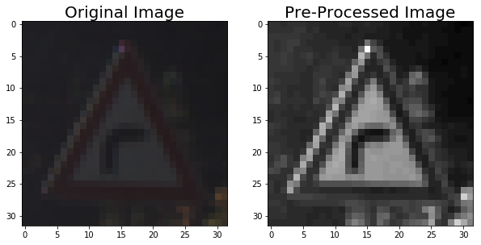

```
Pre_Processing finished!
```

```python
### Preprocess the data here. It is required to normalize the data. Other preprocessing steps could include
### converting to grayscale, etc.
### Feel free to use as many code cells as needed.
import cv2
import matplotlib.image as mpimg
image = randImg(X_train, y_train, 20)
fname = 'Pre-Processed_Image'
# Visualize Pre-Proccessing:
f, (ax1, ax2) = plt.subplots(1, 2, figsize=(10,10))
ax1.imshow(image)
ax1.set_title('Original Image', fontsize=20)
ax2.imshow(processImg(image), cmap='gray')
ax2.set_title('Pre-Processed Image', fontsize=20)
plt.savefig('output_images/'+fname+'.png')
plt.show()
preprocessed = processImg(X_train)
print ('Pre_Processing finished!')
```

### Model Architecture

In this part, we implement the improved LeNet-5 neural network architecture defined in the `dropLeNet` function. First we need to set the parameters for the model architecture.

```python
import tensorflow as tf
from sklearn.utils import shuffle
# Shuffle the training data
X_train, y_train = shuffle(X_train, y_train)

EPOCHS = 120
BATCH_SIZE = 128
DROPOUT = 0.5

keep_prob = tf.placeholder(tf.float32)
x = tf.placeholder(tf.float32, (None, 32, 32, 1))
y = tf.placeholder(tf.int32, (None))
one_hot_y = tf.one_hot(y, 43)
keep_prob = tf.placeholder(tf.float32)
```

### Train, Validate and Test the Model

A validation set can be used to assess how well the model is performing. A low accuracy on the training and validation sets imply underfitting. A high accuracy on the training set but low accuracy on the validation set implies overfitting.

```python
### Train your model here.
### Calculate and report the accuracy on the training and validation set.
### Once a final model architecture is selected,
### the accuracy on the test set should be calculated and reported as well.
### Feel free to use as many code cells as needed.

rate = 0.0008

logits = dropLeNet(x)
cross_entropy = tf.nn.softmax_cross_entropy_with_logits(labels=one_hot_y, logits=logits)
loss_operation = tf.reduce_mean(cross_entropy)
optimizer = tf.train.AdamOptimizer(learning_rate = rate)
training_operation = optimizer.minimize(loss_operation)

correct_prediction = tf.equal(tf.argmax(logits, 1), tf.argmax(one_hot_y, 1))
accuracy_operation = tf.reduce_mean(tf.cast(correct_prediction, tf.float32))
saver = tf.train.Saver()
```

```python
X_train_preProcessed = processImg(X_train)
X_valid_preProcessed = processImg(X_valid)
X_test_preProcessed  = processImg(X_test)

print ('Ready for training!')
```

```
Ready for training!
```

```python
with tf.Session() as sess:
    sess.run(tf.global_variables_initializer())
    num_examples = len(X_train)

    print("Training...")
    print()
    validation_accuracies = []

    for i in range(EPOCHS):
        X_train, X_train_preProcessed, y_train = shuffle(X_train, X_train_preProcessed, y_train)
        for offset in range(0, num_examples, BATCH_SIZE):
            end = offset + BATCH_SIZE
            batch_x, batch_y = X_train_preProcessed[offset:end], y_train[offset:end]
            sess.run(training_operation, feed_dict={x: batch_x, y: batch_y, keep_prob: DROPOUT})

        training_accuracy = evaluate(X_train_preProcessed, y_train)
        validation_accuracy = evaluate(X_valid_preProcessed, y_valid)

        print("EPOCH {} ...".format(i+1))
        print("Training Accuracy = {:.3f}".format(training_accuracy))
        print("Validation Accuracy = {:.3f}".format(validation_accuracy))
        print()
        validation_accuracies.append(validation_accuracy)

    saver.save(sess, './lenet')

    # show learning statistics
    plt.plot(range(EPOCHS),validation_accuracies)
    plt.show

    print("Trained Model saved")
```

[output not shown]

```python
with tf.Session() as sess:
    saver.restore(sess, tf.train.latest_checkpoint('.'))

    test_accuracy = evaluate(X_test_preProcessed, y_test)
    print("Test Accuracy = {:.3f}".format(test_accuracy))
```

```
INFO:tensorflow:Restoring parameters from ./lenet
Test Accuracy = 0.950
```

## Step 3: Test a Model on New Images

To give yourself more insight into how your model is working, download at least five pictures of German traffic signs from the web and use your model to predict the traffic sign type.

You may find `signnames.csv` useful as it contains mappings from the class id (integer) to the actual sign name.

### Load and Output the Images

```
5 new test images with the follwing class ids were loaded:
class ids: [18, 36, 27, 14, 17]
```

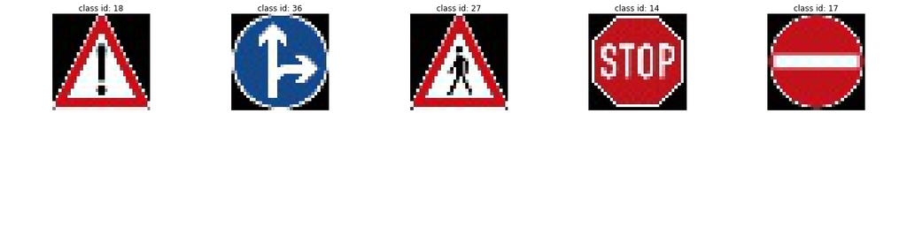

```python
### Load the images and plot them here.
### Feel free to use as many code cells as needed.
import numpy as np
import matplotlib.pyplot as plt
import matplotlib.image as mpimg
import cv2
import glob



test_folder = 'new_test_data/'

newSigns_X = []; newSigns_Y = []
for image_file in glob.glob(test_folder + "*.jpg"):
    image = np.array(mpimg.imread(image_file))
    try:
        # the label is encoded into the first two characters of the file names
        label_str = image_file[len(test_folder):][:2]
        label = int(label_str)
        newSigns_X.append(image)
        newSigns_Y.append(label)
    except  Exception:
        print ('Ignoring image {}'.format(image_file))

display_images(newSigns_X, newSigns_Y, False)

print ('5 new test images with the follwing class ids were loaded:')
print ('class ids: {}'.format(newSigns_Y))
```

### Predict the Sign Type for Each Image

```
INFO:tensorflow:Restoring parameters from ./lenet
Input  class ids  ---> [18, 36, 27, 14, 17]
Output Pricitions ---> [18 36 27 14 17]
```

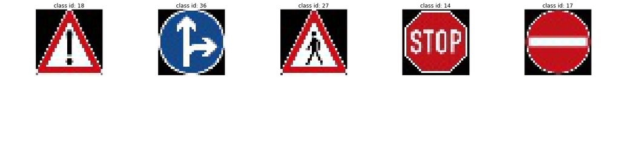

```python
### Run the predictions here and use the model to output the prediction for each image.
### Make sure to pre-process the images with the same pre-processing pipeline used earlier.
### Feel free to use as many code cells as needed.

newSigns_X_preProcessed = processImg(np.array(newSigns_X))

prediction=tf.argmax(logits,1)

with tf.Session() as sess:
    saver.restore(sess, tf.train.latest_checkpoint('.'))
    predictions = sess.run(prediction, feed_dict={x: newSigns_X_preProcessed, keep_prob: 1.0})
    display_images(newSigns_X, predictions, False)

print("Input  class ids ", newSigns_Y, sep=" ---> ")
print("Output Pricitions", predictions, sep=" ---> ")
```

### Analyze Performance

```python
### Calculate the accuracy for these 5 new images.
### For example, if the model predicted 1 out of 5 signs correctly, it's 20% accurate on these new images.

with tf.Session() as sess:
    saver.restore(sess, tf.train.latest_checkpoint('.'))

    test_accuracy = evaluate(newSigns_X_preProcessed, newSigns_Y)
    print("Test Accuracy for 5 new images = {:.3f}".format(test_accuracy))
```

```
INFO:tensorflow:Restoring parameters from ./lenet
Test Accuracy for 5 new images = 1.000
```

### Output Top 5 Softmax Probabilities For Each Image Found on the Web

For each of the new images, I will print out the model's top 5 predictions for each image softmax probabilities to show the **certainty** of the model's predictions.

I will use the `tf.nn.top_k` to find the top k predictions for each image.

```
INFO:tensorflow:Restoring parameters from ./lenet
```

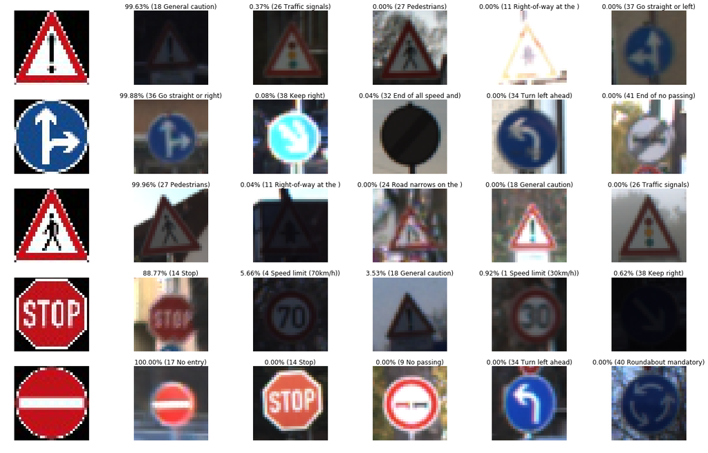

```python
### Print out the top five softmax probabilities for the predictions on the German traffic sign images found on the web.
### Feel free to use as many code cells as needed.

softmax_logits = tf.nn.softmax(logits)
topK_Pridct=tf.nn.top_k(softmax_logits,5)

with tf.Session() as sess:
    saver.restore(sess, tf.train.latest_checkpoint('.'))
    topK_Pridct = sess.run(topK_Pridct, feed_dict={x: newSigns_X_preProcessed, keep_prob : 1.0})

    topPredictionDisp(newSigns_X, X_train, topK_Pridct)
```

## Step 4 (Optional): Visualize the Neural Network's State with Test Images

This Section is for understaning the output of a neural network's weights. While neural networks can be a great learning device they are often referred to as a black box. We can understand what the weights of a neural network look like better by plotting their feature maps. After successfully training your neural network you can see what it's feature maps look like by plotting the output of the network's weight layers in response to a test stimuli image. From these plotted feature maps, it's possible to see what characteristics of an image the network finds interesting. For a sign, maybe the inner network feature maps react with high activation to the sign's boundary outline or to the contrast in the sign's painted symbol.

I have Provided for you below the visualization output of two tensorflow weight convlutional layers. The inputs to the function is an image from the new test data which is shown before.

```
INFO:tensorflow:Restoring parameters from ./lenet
```

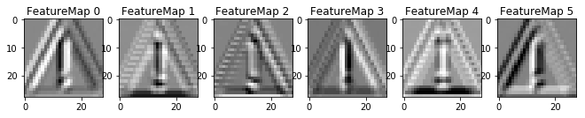

```python
with tf.Session() as sess:
    X_final_graph = newSigns_X_preProcessed
    saver.restore(sess, tf.train.latest_checkpoint('.'))
    conv1 = sess.graph.get_tensor_by_name('Conv2D:0')
    outputFeatureMap(X_final_graph,conv1, activation_min=-1, activation_max=-1, plt_num=1)

    """
    To get all the get_tensor_by_name:

    >> for op in sess.graph.get_operations():
    >>    print(op.name)
    """
```

```
INFO:tensorflow:Restoring parameters from ./lenet
```

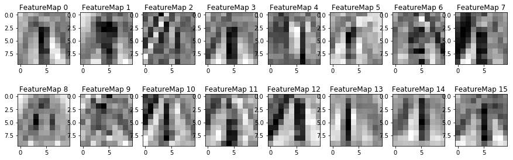

```python
with tf.Session() as sess:
    X_final_graph = newSigns_X_preProcessed
    saver.restore(sess, tf.train.latest_checkpoint('.'))
    conv2 = sess.graph.get_tensor_by_name('Conv2D_1:0')
    outputFeatureMap(X_final_graph,conv2, activation_min=-1, activation_max=-1, plt_num=1)
```